# R Students Project Notebook

### Load Libraries and Data

```r
library(tidyverse)
library(sf)
library(lubridate)
library(tidytext)
library(scales)
library(viridis)

# Load the single, final clean file
inspections <- read_csv("data/inspections_clean.csv")
```

## EDA Report

### Basic Plots

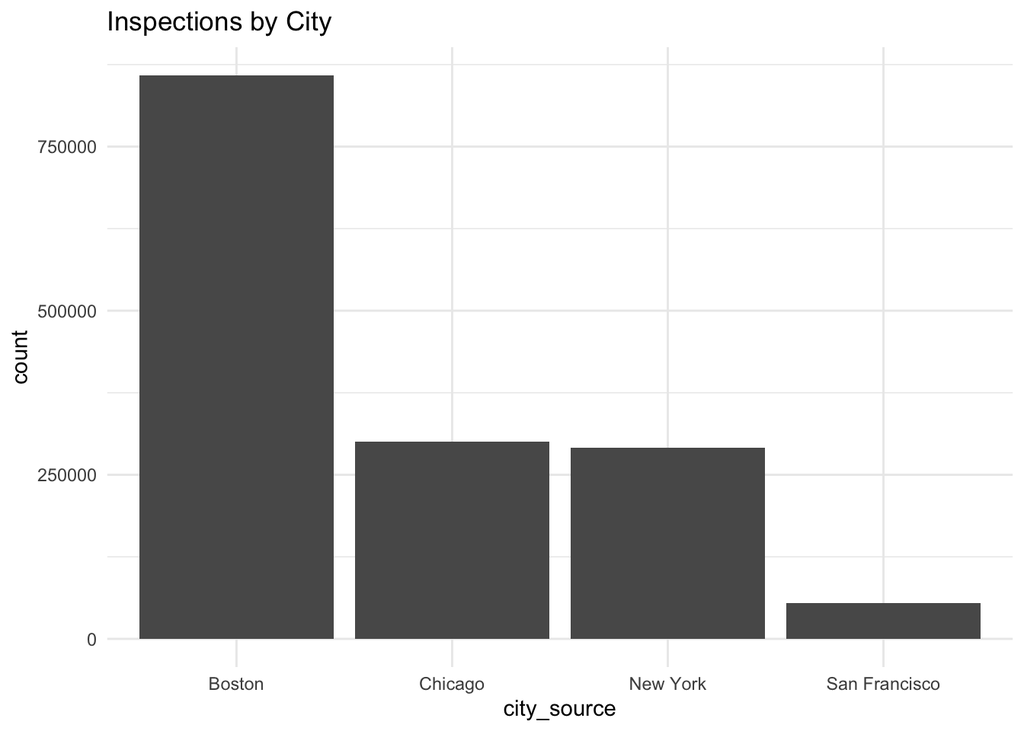

```r
# Inspections by City
ggplot(inspections, aes(x = city_source)) + geom_bar() + labs(title = "Inspections by City") + theme_minimal()
```

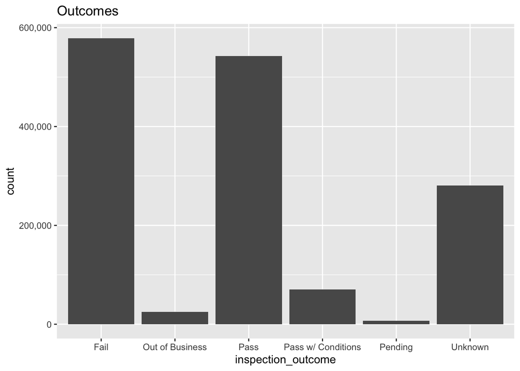

```r
#Outcomes
ggplot(inspections, aes(x = inspection_outcome)) +
  geom_bar() +
  scale_y_continuous(labels = label_comma()) +
  labs(title = "Outcomes")
```

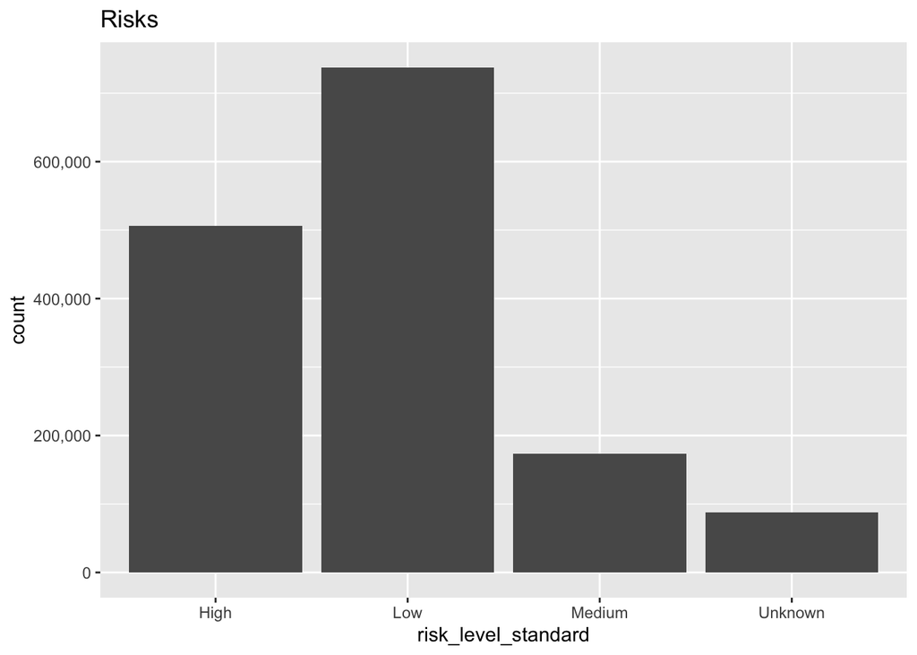

```r
#Risks
ggplot(inspections, aes(x = risk_level_standard)) +
  labs(title = "Risks") +
  scale_y_continuous(labels = label_comma()) +
  geom_bar()
```

```
## Warning: Removed 6398 rows containing non-finite outside the scale range
## (`stat_bin()`).
```

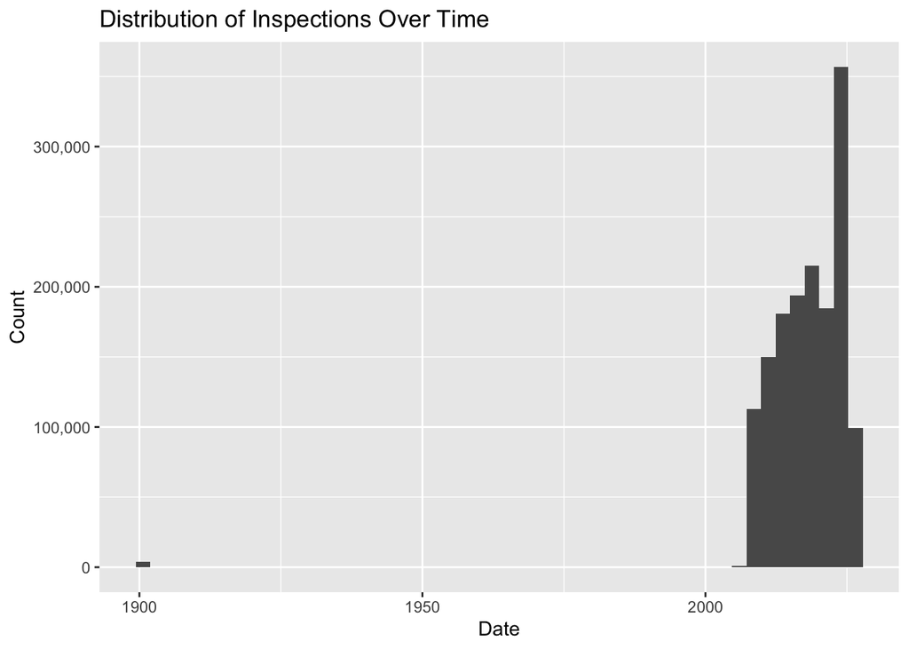

```r
#Time Range of the Data
ggplot(inspections, aes(x = inspection_date)) + geom_histogram(bins = 50) +
scale_y_continuous(labels = label_comma()) +
  labs(title = "Distribution of Inspections Over Time", x = "Date", y = "Count")
```

### City Comparisons

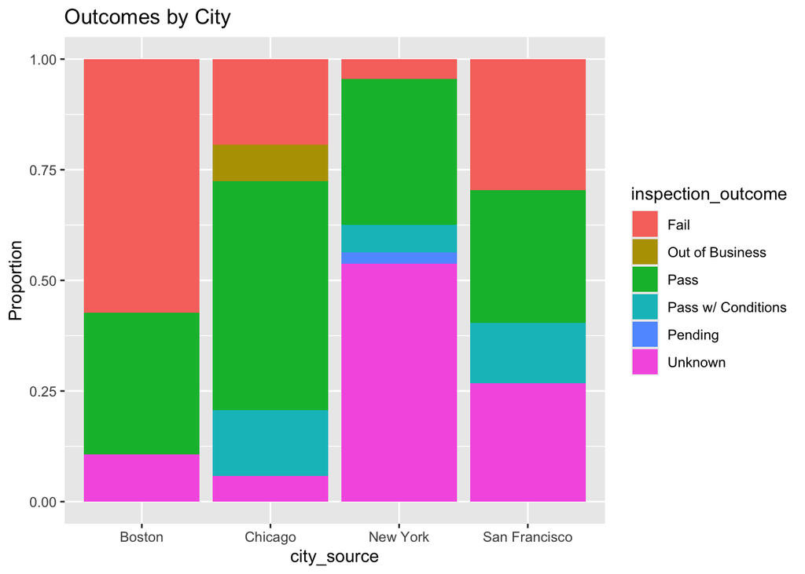

```r
#Outcomes by City
ggplot(inspections, aes(x = city_source, fill = inspection_outcome)) +
  geom_bar(position = "fill") +
  labs(title = "Outcomes by City", y = "Proportion")
```

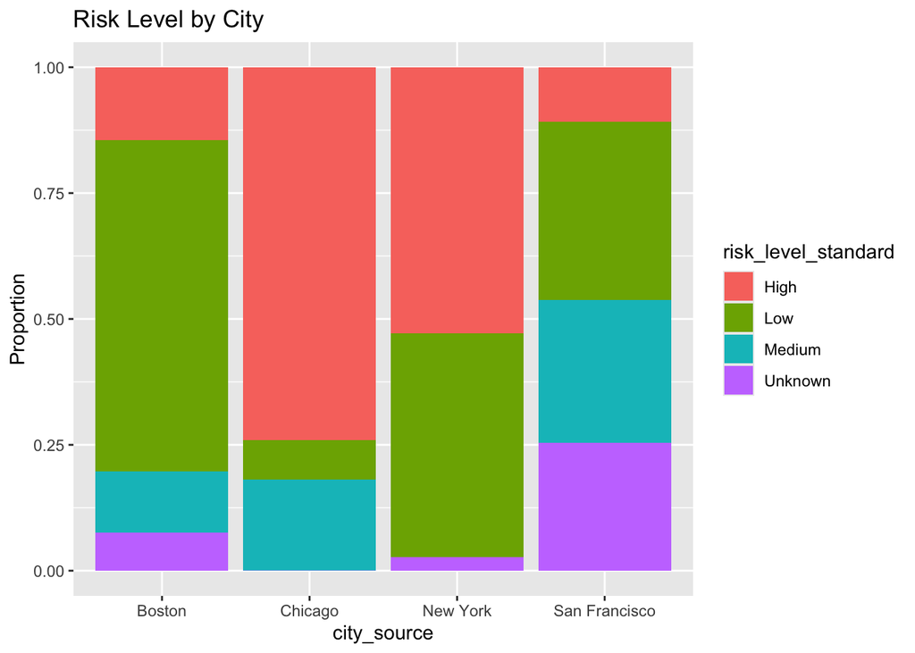

```r
#Risk Level by City
ggplot(inspections, aes(x = city_source, fill = risk_level_standard)) +
  geom_bar(position = "fill") +
    labs(title = "Risk Level by City", y = "Proportion")
```

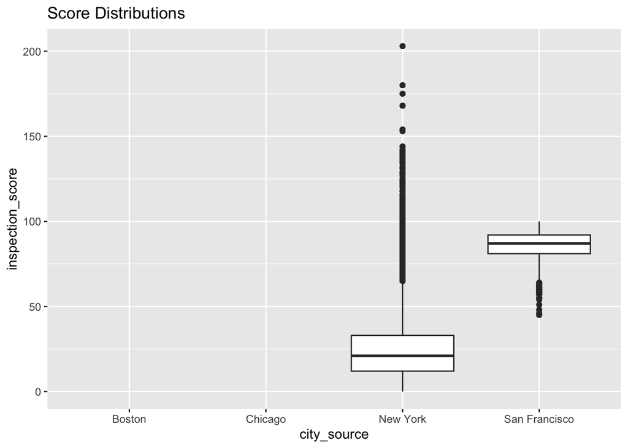

```r
#Score Distributions
ggplot(inspections, aes(x = city_source, y = inspection_score)) +
  geom_boxplot() +
    labs(title = "Score Distributions")
```

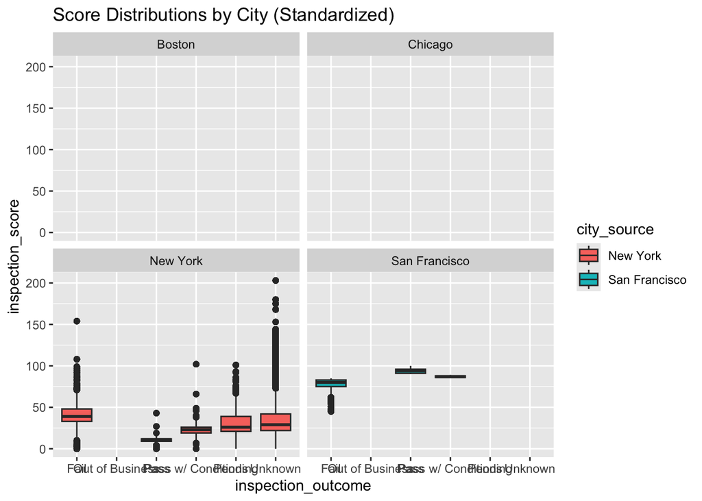

```r
ggplot(inspections, aes(x = inspection_outcome, y = inspection_score, fill = city_source)) +
  geom_boxplot() +
  facet_wrap(~ city_source) +
    labs(title = "Score Distributions by City (Standardized)")
```

After establishing the overall shape of our data, we drilled down to compare the four cities. This is where our standardization efforts provide their first major insights, revealing that the cities have vastly different inspection profiles.

### Exploring Fail Rates Over Time

```r
# Create a summary table
fails_by_year <- inspections |>
  filter(inspection_date > "2000-01-01") |>
  mutate(year = year(inspection_date)) |>
  group_by(city_source, year) |>
  summarize(
    fail_rate = mean(inspection_outcome == "Fail", na.rm = TRUE),
    total_inspections = n()
  ) |>
  filter(total_inspections > 100)
```

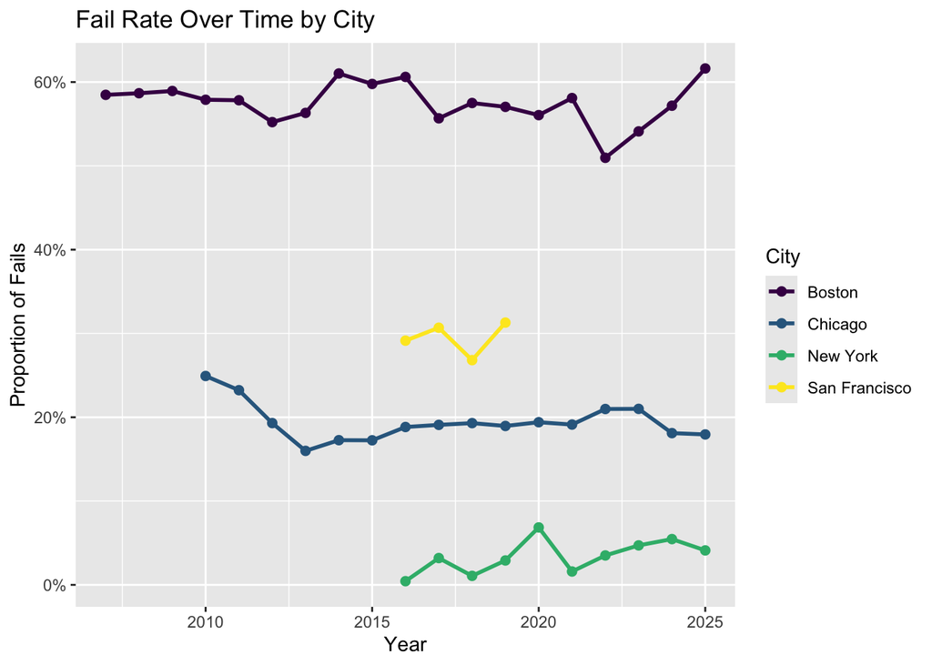

```r
# Plot the summary
ggplot(fails_by_year, aes(x = year, y = fail_rate, color = city_source)) +
  geom_line(linewidth = 1) +
  geom_point(size = 2) +
  scale_y_continuous(labels = label_percent()) +
  scale_color_viridis_d() +
  labs(
    title = "Fail Rate Over Time by City",
    y = "Proportion of Fails",
    x = "Year",
    color = "City"
  )
```

```r
# Least Successful zipcodes in each city in the dataset
fails_by_zip <- inspections |>
  filter(inspection_date > "2000-01-01") |>
  group_by(city_source, zip_code) |>
  summarize(
    fail_rate = mean(inspection_outcome == "Fail", na.rm = TRUE),
    total_inspections = n()
  ) |>
  filter(total_inspections > 100) |>
  ungroup()
```

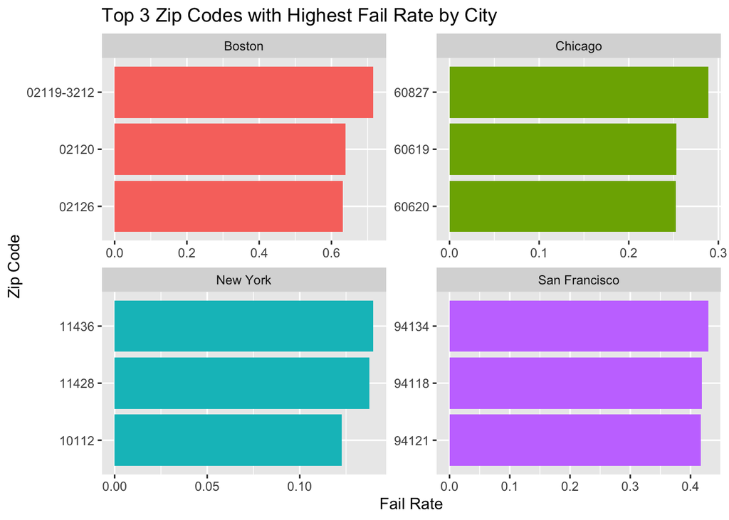

```r
# Summary table for zip codes
fails_by_zip |>
  group_by(city_source) |>
  top_n(3, fail_rate) |>
  ungroup() |>
    mutate(
    zip_code = tidytext::reorder_within(zip_code, fail_rate, city_source)
  ) |>

  ggplot(aes(x = zip_code, y = fail_rate, fill = city_source)) +
  geom_col() +
  tidytext::scale_x_reordered() +
  facet_wrap(~ city_source, scales = "free") +
  coord_flip() +
  labs(
    title = "Top 3 Zip Codes with Highest Fail Rate by City",
    x = "Zip Code",
    y = "Fail Rate"
  ) +
  theme(legend.position = "none")
```

Following our city-level comparisons, we moved into our first multivariate analysis to answer our research questions about where and when violations occur.

### Days of the week that see the most inspections

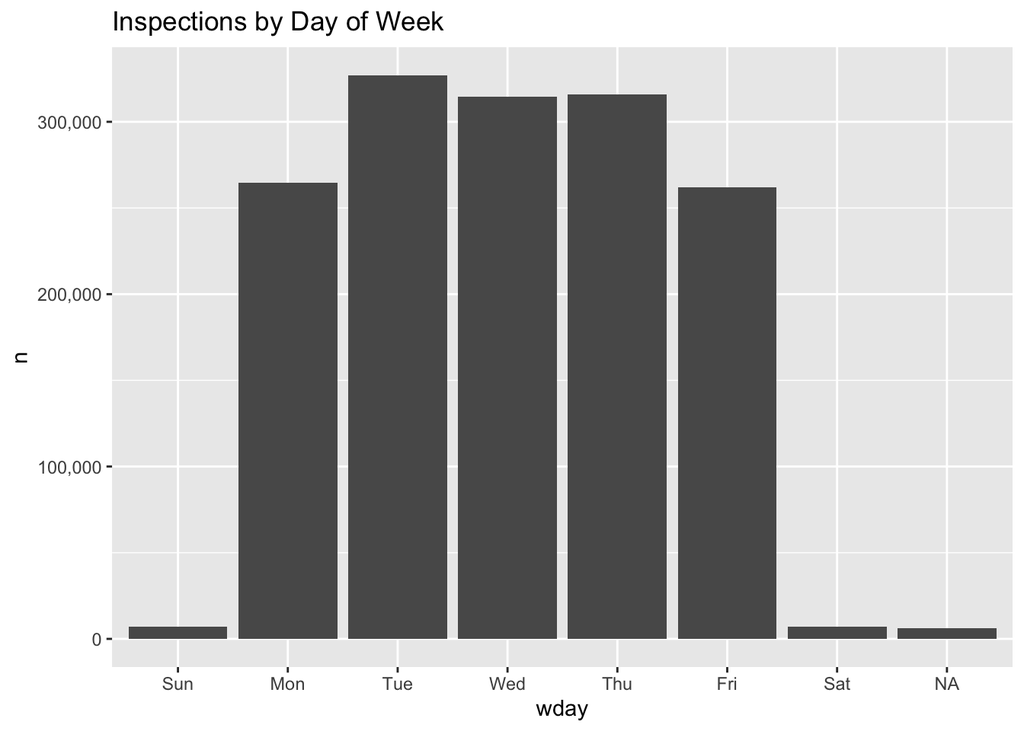

```r
inspections |>
  mutate(wday = wday(inspection_date, label = TRUE)) |>
  count(wday) |>
  ggplot(aes(wday, n)) +
  geom_col() +
  scale_y_continuous(labels = label_comma()) +
  labs(title = "Inspections by Day of Week")
```

### Inspection Frequency per Restaurant

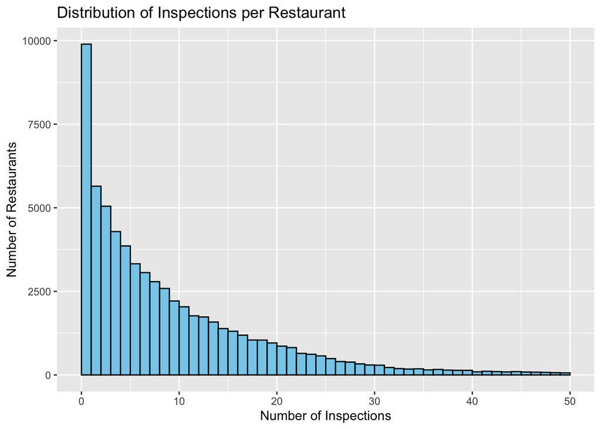

```r
ggplot(inspections |> count(restaurant_name), aes(n)) +
  geom_histogram(breaks = seq(0, 50, by = 1), color="black", fill="skyblue") +
  labs(title="Distribution of Inspections per Restaurant", x="Number of Inspections", y="Number of Restaurants")
```

The tallest bar shows that nearly 10,000 restaurants have been inspected only once (or close to once) during the dataset’s time frame. The number of restaurants drops off steeply for businesses inspected just 2, 3, or 4 times.

## Answering Research Questions

## Seun’s Analysis

### Top Violation Phrases

```r
get_bigram_counts <- function(data_chunk) {
  data_chunk |>
  filter(!is.na(violation_desc)) |>
  unnest_tokens(bigram, violation_desc, token = "ngrams", n = 2) |>
  separate(bigram, c("word1", "word2"), sep = " ") |>
  anti_join(stop_words, by = c("word1" = "word")) |>
  anti_join(stop_words, by = c("word2" = "word")) |>
  unite(bigram, word1, word2, sep = " ") |>
  count(bigram, sort = TRUE)
}

#partitioning data into 10 chunks for faster processing time
all_segment_counts <- list()
num_segments <- 10
sample_fraction <- 0.1
for (i in 1:num_segments) {
  message(paste("Processing Segment", i, "of", num_segments))
    data_segment <- inspections |>
    sample_frac(sample_fraction)
    segment_result <- get_bigram_counts(data_segment)
    all_segment_counts[[i]] <- segment_result
}
```

```
## Processing Segment 1 of 10
```

```
## Processing Segment 2 of 10
```

```
## Processing Segment 3 of 10
```

```
## Processing Segment 4 of 10
```

```
## Processing Segment 5 of 10
```

```
## Processing Segment 6 of 10
```

```
## Processing Segment 7 of 10
```

```
## Processing Segment 8 of 10
```

```
## Processing Segment 9 of 10
```

```
## Processing Segment 10 of 10
```

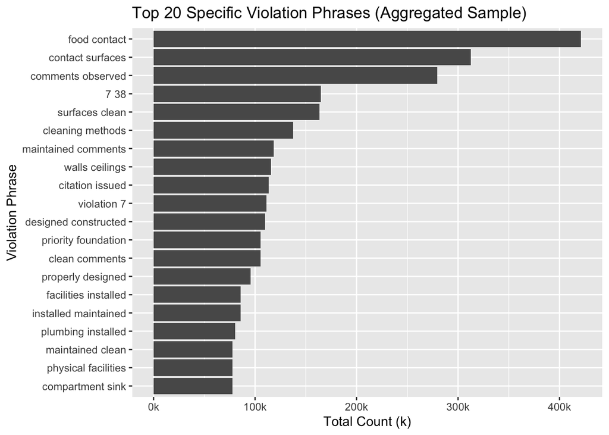

```r
top_bigrams <- all_segment_counts |>
  bind_rows() |>
  group_by(bigram) |>
  summarize(n = sum(n), .groups = "drop") |>
  arrange(desc(n))

# Plot the top 20
top_bigrams |>
  slice_head(n = 20) |>
  ggplot(aes(x = reorder(bigram, n), y = n)) +
  geom_col() +
  coord_flip() +
  scale_y_continuous(labels=label_number(scale = 1/1000, suffix = "k")) +
  labs(
    title = "Top 20 Specific Violation Phrases (Aggregated Sample)",
    x = "Violation Phrase",
    y = "Total Count (k)"
  )
```

The chart reveals that the most frequent violations found by inspectors are not specific health emergencies but rather structural, maintenance, and sanitation compliance issues.

### Categorize Violations

```r
inspections_categorized <- inspections |>
  mutate(
    violation_category = case_when(
      str_detect(violation_desc, "mice|rodent|droppings|insects|pests|harborage") ~ "Pest Control",
      str_detect(violation_desc, "temperature|cool|hot-holding|cold-holding|refrigerat") ~ "Food Temperature",
      str_detect(violation_desc, "wash|sanitiz|clean|wiping cloths|dishwashing") ~ "Sanitation & Cleaning",
      str_detect(violation_desc, "hand wash|hygiene|no hair|bare hand") ~ "Employee Hygiene",
      str_detect(violation_desc, "contaminat|cross-contamination|raw|covered|protect") ~ "Cross-Contamination",
      str_detect(violation_desc, "floor|wall|ceiling|plumbing|ventilation|garbage") ~ "Facility/Maintenance",
      TRUE ~ "Other"
    )
  )

#Check new categories
inspections_categorized |>
  count(violation_category, sort = TRUE)
```

| violation_category | n |
| --- | --- |
| Other | 614830 |
| Sanitation & Cleaning | 379871 |
| Food Temperature | 147897 |
| Pest Control | 132012 |
| Facility/Maintenance | 124497 |
| Cross-Contamination | 104102 |
| Employee Hygiene | 1231 |

### Categorize Restaurants

```r
inspections_categorized <- inspections_categorized |>
  mutate(
    # Create one combined description column to search
    desc_all = coalesce(cuisine_description, facility_type, descript) |> tolower(),

    restaurant_category = case_when(
      str_detect(desc_all, "pizza|pizzeria") ~ "Pizza",
      str_detect(desc_all, "sushi|japanese") ~ "Sushi/Japanese",
      str_detect(desc_all, "coffee|cafe|bakery|donut") ~ "Coffee/Bakery",
      str_detect(desc_all, "mexican|taco") ~ "Mexican",
      str_detect(desc_all, "chinese") ~ "Chinese",
      str_detect(desc_all, "sandwich|deli|sub") ~ "Sandwich/Deli",
      str_detect(desc_all, "bar|tavern|pub") ~ "Bar/Pub",
      str_detect(desc_all, "restaurant|american") ~ "Restaurant (General)",
      str_detect(desc_all, "school|grocery|market|caterer|kitchen") ~ "Other (Grocery/School/Etc.)",
      TRUE ~ "Other"
    )
  )

#Check new categories
inspections_categorized |>
  count(restaurant_category, sort = TRUE)
```

| restaurant_category | n |
| --- | --- |
| Other | 1066308 |
| Restaurant (General) | 262665 |
| Other (Grocery/School/Etc.) | 56917 |
| Coffee/Bakery | 41390 |
| Chinese | 28658 |
| Pizza | 17372 |
| Mexican | 11989 |
| Sushi/Japanese | 10901 |
| Sandwich/Deli | 7027 |
| Bar/Pub | 1213 |

### Violation “Fingerprint” Plot

```r
# Ensures bars stack hierarchically (High, Medium, Low)
inspections_categorized <- inspections_categorized |>
  mutate(
    risk_level_standard = factor(
      risk_level_standard,
      levels = c("High", "Medium", "Low", "Unknown"),
      ordered = TRUE
    )
  )

#Summary table
violation_fingerprint <- inspections_categorized |>
  filter(
    restaurant_category != "Other",
    restaurant_category != "Other (Grocery/School/Etc.)",
    violation_category != "Other"
  ) |>
  count(restaurant_category, violation_category) |>
  group_by(restaurant_category) |>
  mutate(proportion = n / sum(n)) |>
  ungroup()

# Plot the "fingerprint"
ggplot(violation_fingerprint,
       aes(x = violation_category, y = proportion, fill = violation_category)) +
  geom_col() +
  facet_wrap(~ restaurant_category) +
  scale_y_continuous(labels = label_percent()) +
  theme(
    axis.text.x = element_blank(),
    axis.ticks.x = element_blank(),
    legend.position = "bottom"
  ) +
  labs(
    title = "Violation 'Fingerprint' by Restaurant Category",
    y = "Proportion of All Violations",
    x = "Violation Type",
    fill = "Violation Category"
  )
```

[output not shown]

### Standardize Inspection Types

```r
inspections_categorized <- inspections_categorized |>
  mutate(
    type_lower = tolower(inspection_type),

    inspection_type_standard = case_when(
      # Keywords for complaint
      str_detect(type_lower, "complaint|311|owner complaint") ~ "Complaint",

      # Keywords for routine
      str_detect(type_lower, "routine|cycle|canvass|regular") ~ "Routine",

      # Keywords for follow-ups
      str_detect(type_lower, "re-inspection|reinspection|follow-up") ~ "Follow-Up",

      TRUE ~ "Other"
    )
  )

#new standardized categories
inspections_categorized |>
  count(inspection_type_standard, sort = TRUE)
```

| inspection_type_standard | n |
| --- | --- |
| Other | 973246 |
| Routine | 446639 |
| Complaint | 51875 |
| Follow-Up | 32680 |

### Plot Severity by Inspection Type

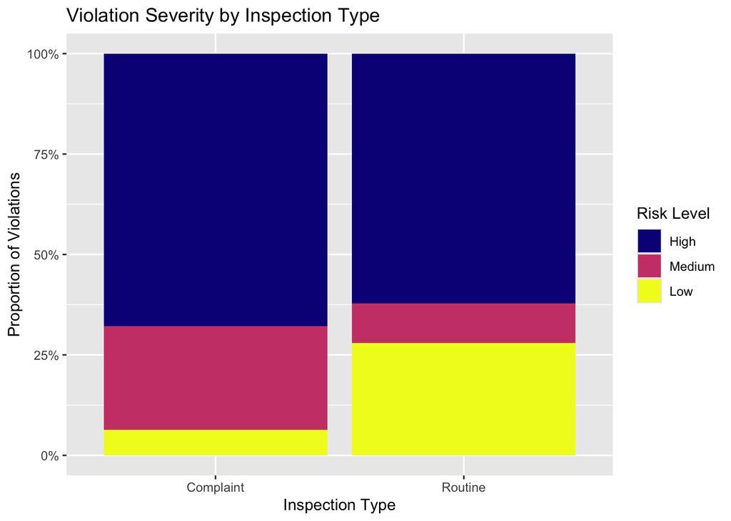

```r
inspections_categorized |>
  filter(
    inspection_type_standard %in% c("Routine", "Complaint"),
    risk_level_standard != "Unknown"
  ) |>
  # NOTE: The mutate is now outside this chunk to save the factor conversion globally.
  ggplot(aes(x = inspection_type_standard, fill = risk_level_standard)) +
  geom_bar(position = "fill") +
  scale_y_continuous(labels = scales::label_percent()) +
  scale_fill_viridis_d(option = "C") +
  labs(
    title = "Violation Severity by Inspection Type",
    x = "Inspection Type",
    y = "Proportion of Violations",
    fill = "Risk Level"
  )
```

The proportional plot clearly shows that Complaint-Driven inspections are more likely to find severe problems than Routine inspections. The proportion of Medium Risk violations is visually larger in the Complaint column than in the Routine column.

## Plot Violation Type by Inspection Type

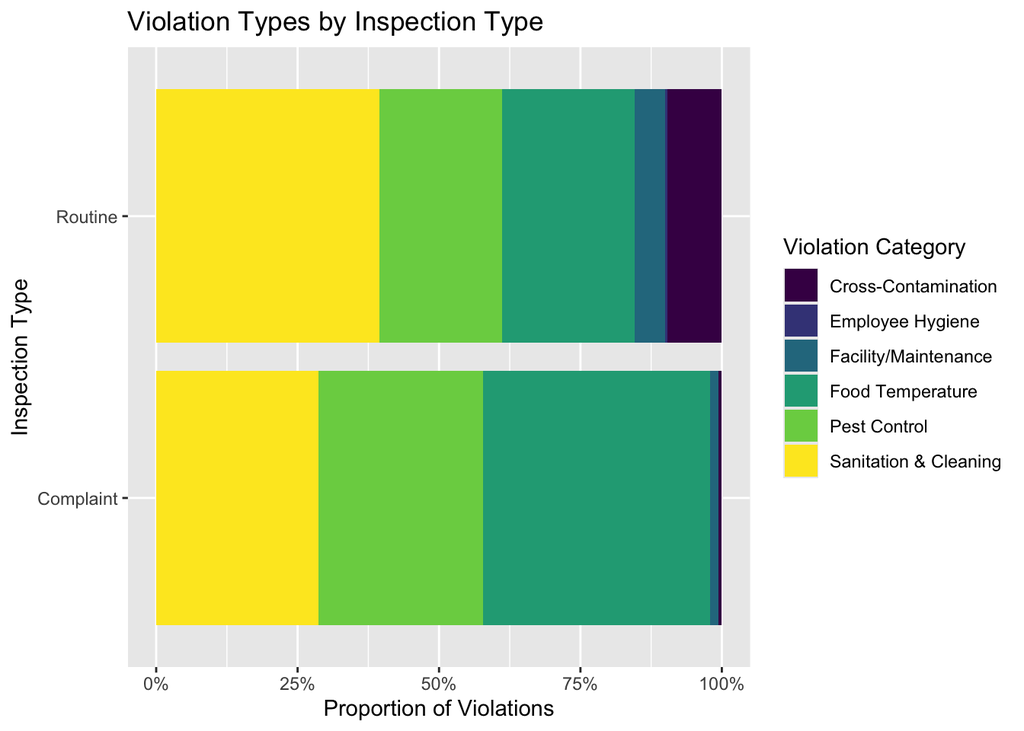

```r
inspections_categorized |>
  filter(
    inspection_type_standard %in% c("Routine", "Complaint"),
    violation_category != "Other" # Remove 'Other' violations
  ) |>
  ggplot(aes(x = inspection_type_standard, fill = violation_category)) +
  geom_bar(position = "fill") +
  scale_y_continuous(labels = scales::label_percent()) +
  scale_fill_viridis_d() +
  labs(
    title = "Violation Types by Inspection Type",
    x = "Inspection Type",
    y = "Proportion of Violations",
    fill = "Violation Category"
  ) +
  coord_flip() # Flipped axes to make categories easier to read
```

When looking at violation type, Complaint inspections are disproportionately focused on Pest Control and Food Temperature issues. In contrast, Routine inspections find a much higher proportion of Sanitation & Cleaning and Facility/Maintenance problems. This suggests that patrons are quick to report visible signs of pests or temperature issues, while inspectors find more structural/hygiene problems during unannounced, comprehensive checks.

## Arohi’s question and analysis

For my analysis, I am focusing on time-series data. As we saw in our Exploratory Data Analysis (EDA), the data is relatively recent, tracing back to around 2005 onwards, which works well for inspecting modern trends.

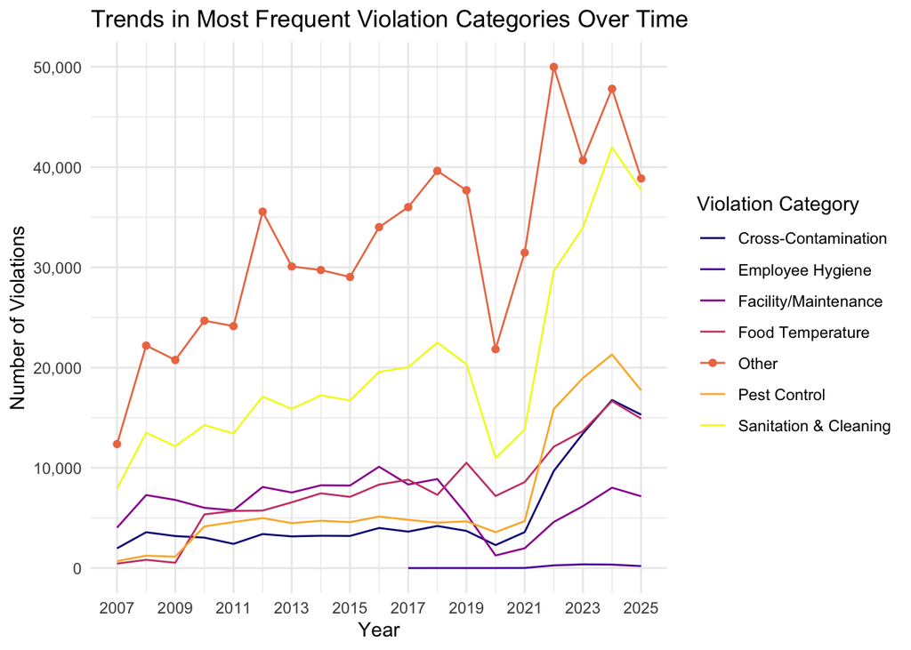

```r
# Extract years and categorize violations appropriately
inspections_over_time <- inspections |>
  mutate(
    year = year(inspection_date),
    violation_category = case_when(
      str_detect(violation_desc, "mice|rodent|droppings|insects|pests|harborage") ~ "Pest Control",
      str_detect(violation_desc, "temperature|cool|hot-holding|cold-holding|refrigerat") ~ "Food Temperature",
      str_detect(violation_desc, "wash|sanitiz|clean|wiping cloths|dishwashing") ~ "Sanitation & Cleaning",
      str_detect(violation_desc, "hand wash|hygiene|no hair|bare hand") ~ "Employee Hygiene",
      str_detect(violation_desc, "contaminat|cross-contamination|raw|covered|protect") ~ "Cross-Contamination",
      str_detect(violation_desc, "floor|wall|ceiling|plumbing|ventilation|garbage") ~ "Facility/Maintenance",
      TRUE ~ "Other"
    )
  ) |>

# Filter out appropriate years due to 1900 "outlier" (no available data between 1900 and 2007)
filter(year >= 2007, year <= 2025)

# Count violations per year and per category
violation_trends <- inspections_over_time |>
  group_by(year, violation_category) |>
  summarise(count = n(), .groups = "drop") |>
  arrange(year, desc(count))

# Most frequent violations per year
most_frequent_by_year <- violation_trends |>
  group_by(year) |>
  slice_max(order_by = count, n = 1) |>
  ungroup()

# Plot
ggplot(violation_trends, aes(x = year, y = count, color = violation_category, group = violation_category)) +
  geom_line() +
  geom_point(data = most_frequent_by_year, aes(x = year, y = count)) +
  scale_color_viridis_d(option = "C") +
  scale_y_continuous(labels = comma) +
  scale_x_continuous(
    breaks = seq(2007, 2025, by = 2),
    labels = seq(2007, 2025, by = 2)
  ) +
  labs(title = "Trends in Most Frequent Violation Categories Over Time", x = "Year", y = "Number of Violations", color = "Violation Category") +
  theme_minimal()
```

We can see that Other is the largest category for most frequent violations per year consistently since the data has been tracked. This makes sense because the tracking methodology is not universal between Boston, NYC, Chicago, and SF, as we found in our EDA, so Other encapsulates all the data inspections unmarked by the categories included.

```r
# Most common violation in 2015 and 2020, for example, to see the effect of environmental circumstances (COVID-19) on violation frequency.

years_to_compare <- c(2015, 2020)

# Compare top category (which is Other, calculated in our previous code) in each year
violation_compare <- inspections_over_time |>
  filter(year %in% years_to_compare) |>
  group_by(year, violation_category) |>
  summarise(count = n(), .groups = "drop") |>
  group_by(year) |>
  slice_max(order_by = count, n = 1) |>
  ungroup()

violation_compare
```

| year | violation_category | count |
| --- | --- | --- |
| 2015 | Other | 29039 |
| 2020 | Other | 21836 |

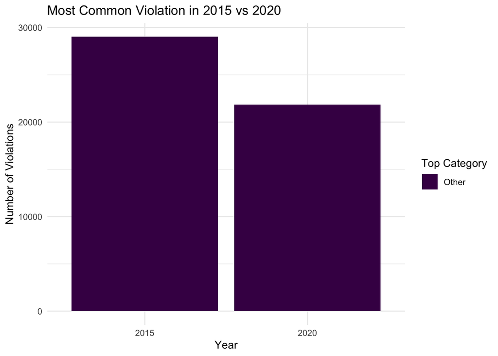

```r
# Plot
ggplot(violation_compare, aes(x = factor(year), y = count, fill = violation_category)) + geom_col() +
  scale_fill_viridis_d() +
  labs(title = "Most Common Violation in 2015 vs 2020", x = "Year", y = "Number of Violations", fill = "Top Category") +
  theme_minimal()
```

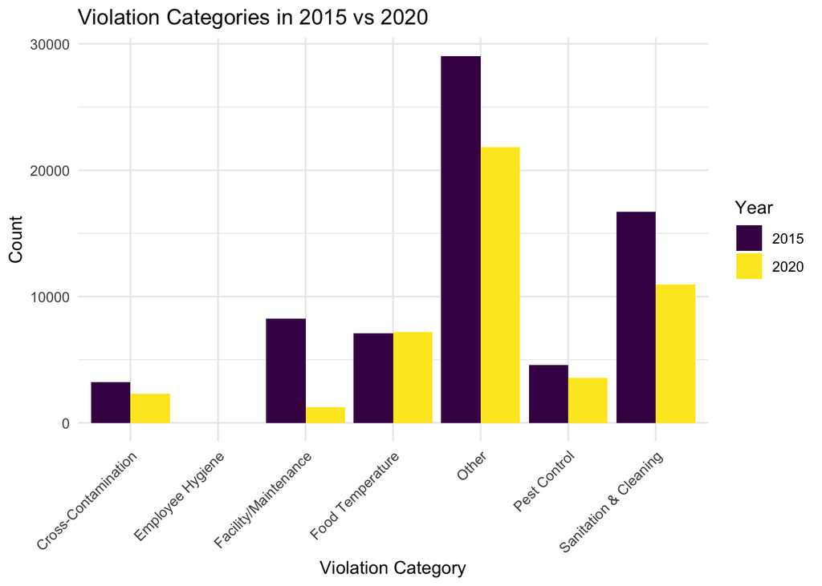

```r
# Now, let's take a look at the side by side comparison in all violation categories within 2015 and 2020, not just the top one.

# Count each violation category in each year
violation_compare_all <- inspections_over_time |>
  filter(year %in% years_to_compare) |>
  group_by(year, violation_category) |>
  summarise(count = n(), .groups = "drop")

# Plot
ggplot(violation_compare_all, aes(x = violation_category, y = count, fill = factor(year))) +
  geom_col(position = "dodge") +
  scale_fill_viridis_d() +
  labs(title = "Violation Categories in 2015 vs 2020", x = "Violation Category", y = "Count", fill = "Year") +
  theme_minimal() +
  theme(axis.text.x = element_text(angle = 45, hjust = 1))
```

```r
# Calculating which violations grew the most in 2015 vs 2020
violation_diff <- violation_compare_all |>
  pivot_wider(names_from = year, values_from = count, values_fill = 0) |>
  mutate(change = `2020` - `2015`)

violation_diff
```

| violation_category | 2015 | 2020 | change |
| --- | --- | --- | --- |
| Cross-Contamination | 3208 | 2296 | -912 |
| Facility/Maintenance | 8236 | 1262 | -6974 |
| Food Temperature | 7105 | 7193 | 88 |
| Other | 29039 | 21836 | -7203 |
| Pest Control | 4584 | 3583 | -1001 |
| Sanitation & Cleaning | 16727 | 10975 | -5752 |
| Employee Hygiene | 0 | 7 | 7 |

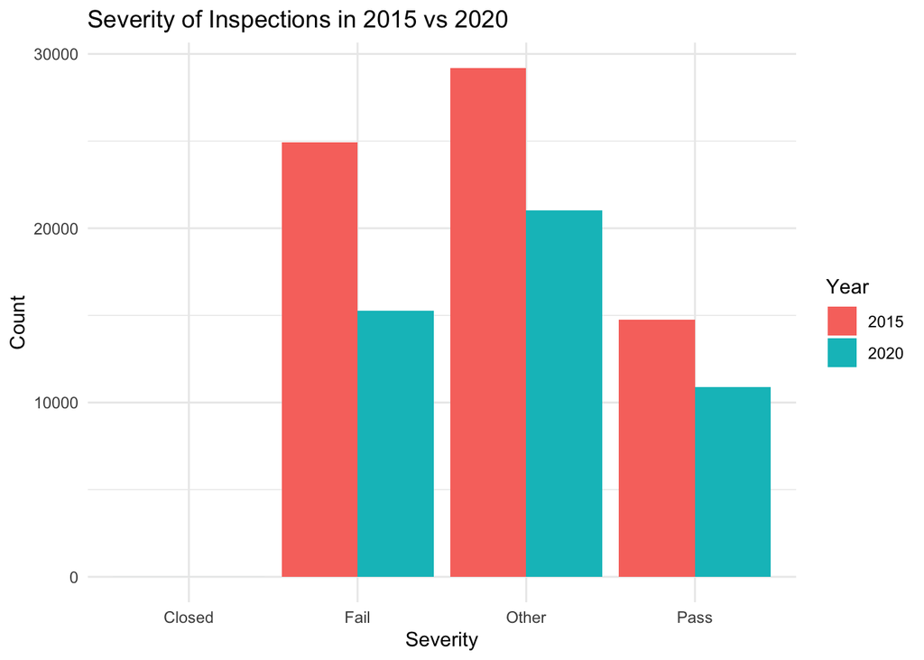

```r
# We can also look at the violations from a severity perspective

# Create a variable assigning severity by categories in dataset: Fail, Closed, Violation, Pass, and Other
inspections_over_time <- inspections_over_time |>
  mutate(
    severity = case_when(
      str_detect(tolower(result), "fail") ~ "Fail",
      str_detect(tolower(result), "closed") ~ "Closed",
      str_detect(tolower(result), "violation") ~ "Violation",
      str_detect(tolower(result), "pass") ~ "Pass",
      TRUE ~ "Other"
      )
  )

# Plot
inspections_over_time |>
  filter(year %in% c(2015, 2020)) |>
  ggplot(aes(x = severity, fill = factor(year))) + geom_bar(position = "dodge") +
  labs(title = "Severity of Inspections in 2015 vs 2020", x = "Severity", y = "Count", fill = "Year") +
  theme_minimal()
```

Restaurants under the “Fail” severity category had the second highest count, which is concerning, especially since it exceeded the count of restaurants under the “Pass” severity category.

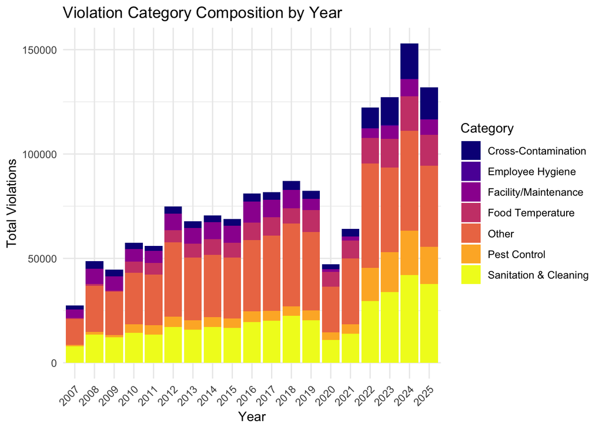

```r
# How does the composition of all violations change year over year?

# Plot
ggplot(violation_trends,aes(x = factor(year), y = count, fill = violation_category)) +
  geom_bar(stat = "identity") +
  scale_fill_viridis_d(option = "C") +
  labs(title = "Violation Category Composition by Year", x = "Year", y = "Total Violations", fill = "Category") +
  theme_minimal() +
  theme(axis.text.x = element_text(angle = 45, hjust = 1))
```

## Niki’s Analysis

### Overall Monthly analysis

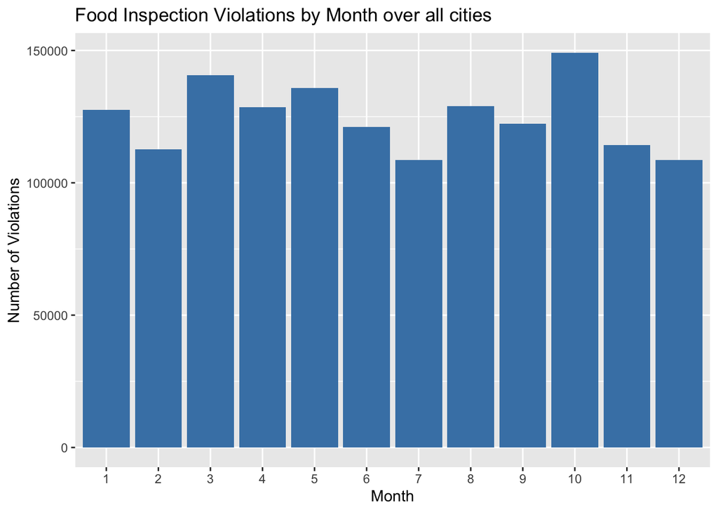

```r
# Categorizing the different inspections for later analysis
inspections_cat <- inspections |>
  mutate(
  violation_category = case_when(
      str_detect(violation_desc, "mice|rodent|droppings|insects|pests|harborage") ~ "Pest Control",
      str_detect(violation_desc, "temperature|cool|hot-holding|cold-holding|refrigerat") ~ "Food Temperature",
      str_detect(violation_desc, "wash|sanitiz|clean|wiping cloths|dishwashing") ~ "Sanitation & Cleaning",
      str_detect(violation_desc, "hand wash|hygiene|no hair|bare hand") ~ "Employee Hygiene",
      str_detect(violation_desc, "contaminat|cross-contamination|raw|covered|protect") ~ "Cross-Contamination",
      str_detect(violation_desc, "floor|wall|ceiling|plumbing|ventilation|garbage") ~ "Facility/Maintenance",
      TRUE ~ "Other"
    )
    )
# Adding columns that tell me the month and what season that month correlates to
monthly_season <- inspections_cat|>
  mutate(month = month(inspection_date), season = case_when(
      month %in% c(12, 1, 2) ~ "Winter",
      month %in% c(3, 4, 5) ~ "Spring",
      month %in% c(6, 7, 8) ~ "Summer",
      month %in% c(9, 10, 11) ~ "Fall"
    )
    )|>
  filter(!is.na(month))

# Food Inspection Violations by Month over all cities
month_count <- monthly_season|>
  group_by(month)|>
  summarise(count = n())

ggplot(month_count, aes(x = factor(month), y = count)) +
  geom_col(fill = "steelblue")+
  labs(
    title = "Food Inspection Violations by Month over all cities",
    x = "Month",
    y = "Number of Violations"
  )
```

### Monthly Analysis by City

```r
# Food Inspection Violations by Month for each city
monthly_city_count <- monthly_season|>
  group_by(city_source, month)|>
  summarise(count = n())
```

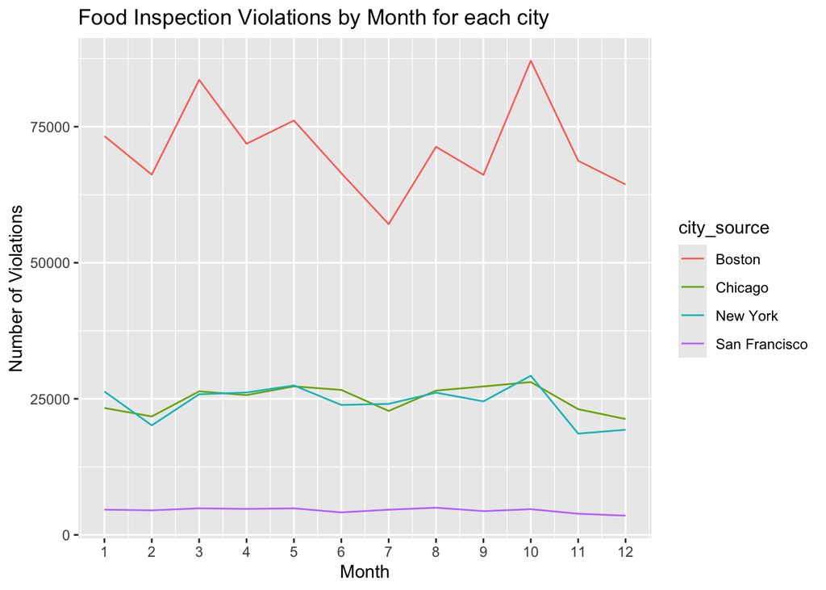

```r
ggplot(monthly_city_count) +
  geom_line(aes(x = month, y = count, color = city_source)) +
  scale_x_continuous(breaks = 1:12)+
  labs(
    title = "Food Inspection Violations by Month for each city",
    x = "Month",
    y = "Number of Violations"
  )
```

### Overall Seasonal Analysis

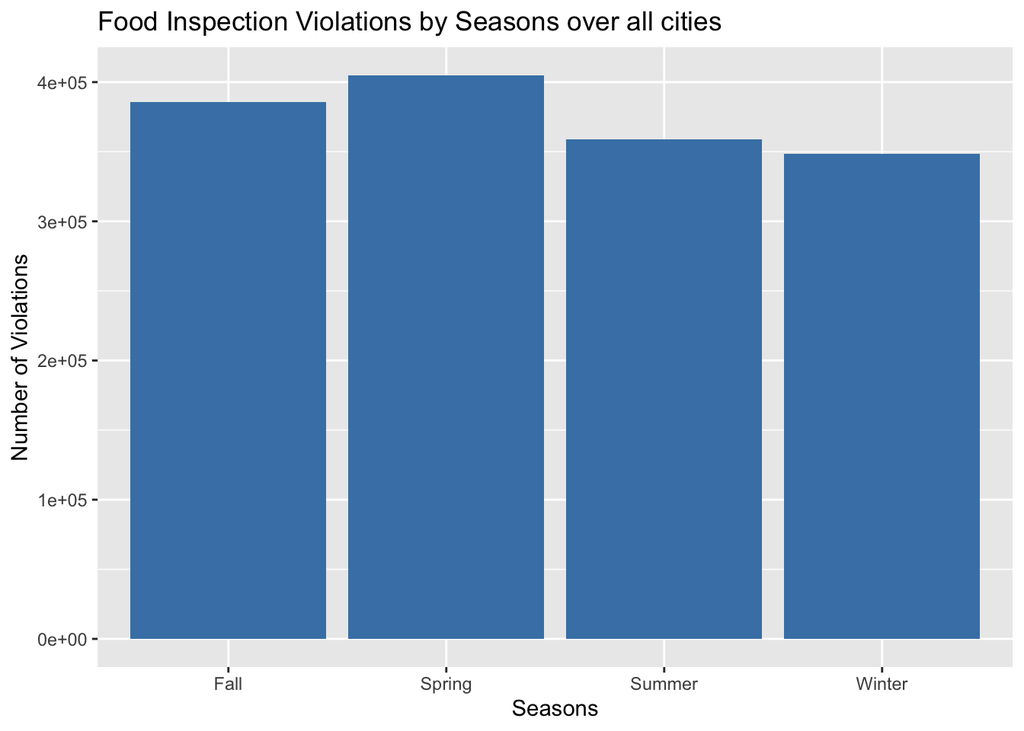

```r
# Food Inspection Violations by Seasons over all cities
seasonal_count <- monthly_season|>
  group_by(season)|>
  summarise(count = n())
ggplot(seasonal_count, aes(x = season, y = count)) +
  geom_col(fill = "steelblue")+
  labs(
    title = "Food Inspection Violations by Seasons over all cities",
    x = "Seasons",
    y = "Number of Violations"
  )
```

### Season Analysis by City

```r
# Food Inspection Violations by Season for each city
seasonal_city_count <- monthly_season|>
  group_by(city_source, season)|>
  summarise(count = n())
```

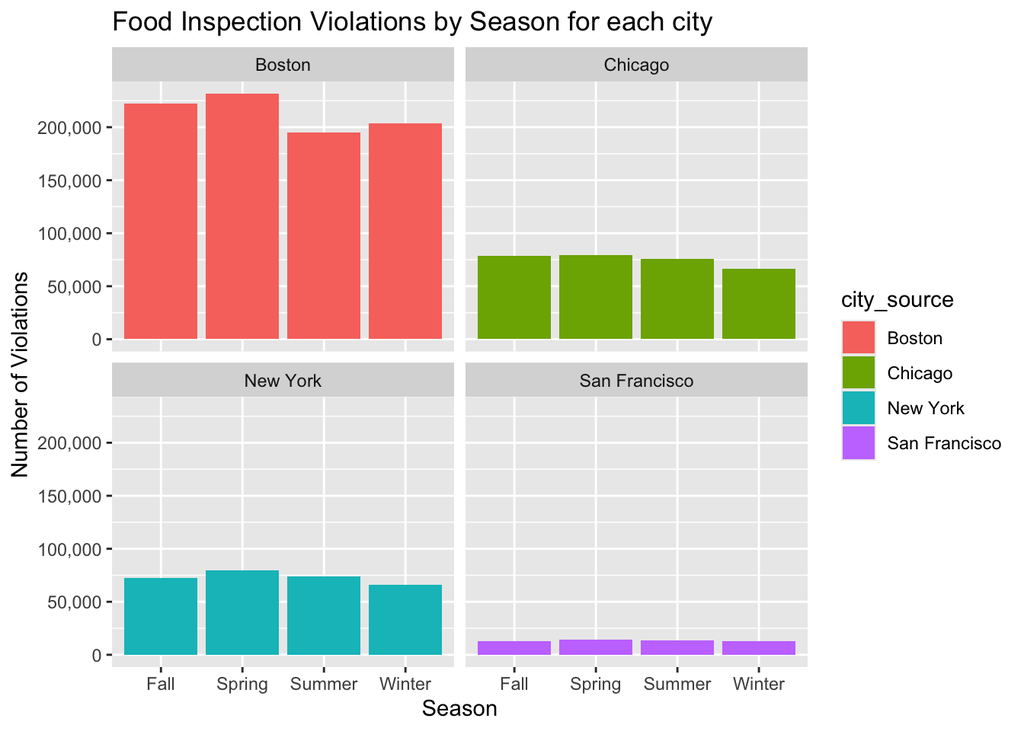

```r
ggplot(seasonal_city_count,
       aes(x = season, y = count, fill = city_source)) +
  geom_col() +
  facet_wrap(~ city_source, nrow = 2) +
  scale_y_continuous(labels = comma) +
  labs(
    title = "Food Inspection Violations by Season for each city",
    x = "Season",
    y = "Number of Violations"
  )
```

### Monthly Trends for Each Violation Category

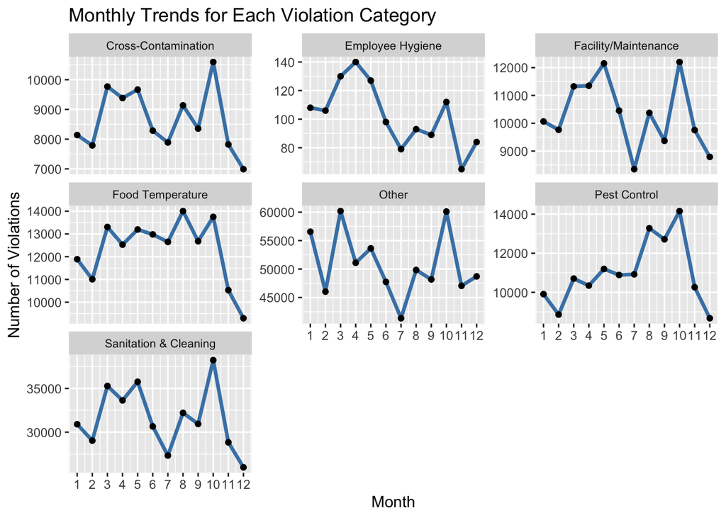

```r
monthly_violation_counts <- monthly_season|>
  filter(!is.na(season),!is.na(violation_category))|>
  group_by(violation_category, month)|>
  summarise(count = n(), .groups = "drop")

ggplot(monthly_violation_counts,
       aes(x = month, y = count, group = violation_category)) +
  geom_line(linewidth = 1.2, color = "steelblue") +
  geom_point() +
  facet_wrap(~ violation_category, scales = "free_y", nrow = 3) +
  scale_x_continuous(breaks = 1:12) +
  theme(
    strip.text = element_text(size = 8)
  ) +
  labs(
    title = "Monthly Trends for Each Violation Category",
    x = "Month",
    y = "Number of Violations"
  )
```

An important exception is Employee Hygiene, which peaks in April rather than October. This may reflect seasonal staffing changes, onboarding of new employees in the spring, or changes in enforcement focus.

### Seasonal Distribution for Each Violation Category

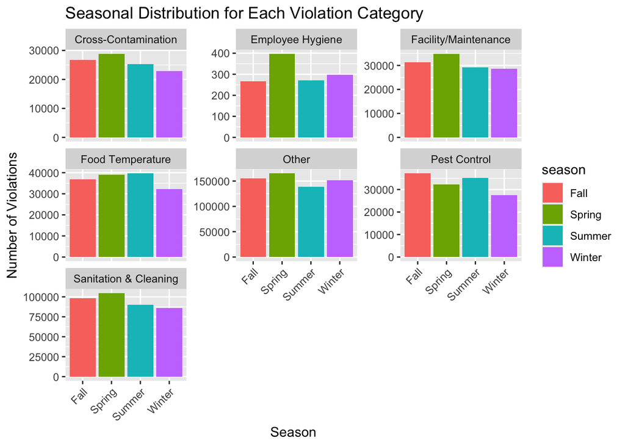

```r
season_violation_counts <- monthly_season|>
  filter(!is.na(season),!is.na(violation_category))|>
  group_by(violation_category, season)|>
  summarise(count = n(), .groups = "drop")

ggplot(season_violation_counts,
       aes(x = season, y = count, fill = season)) +
  geom_col() +
  facet_wrap(~ violation_category, scales = "free_y", nrow = 3) +
  theme(axis.text.x = element_text(angle = 45, hjust = 1))+
  labs(
    title = "Seasonal Distribution for Each Violation Category",
    x = "Season",
    y = "Number of Violations"
  )
```

An important exception is Pest Control and Food Temperatrure. Pest control violations peak in the fall, likely because colder outdoor temperatures drive rodents and insects indoors, increasing the risk of infestations in food establishments.